# HACL Final Project Notebook Template

COVID-Twitter

Yucheng Zhang

10 August 2020

## Work Summary

**NOTE:** Follow an outline format; use bullets to express individual points.

- RCS ID: zhangy68
- Project Name: COVID-Twitter
- Summary of Work
  - Researched articles on coronavirus tweet data analysis and mask sentiment in the US
  - Did statistical analysis on mean sentiment of tweets per week over time, and will do a statstical analysis on mean sentiment of anti and positive mask sentiment tweets per week over time
- Summary of github contributions
  - Weekly notebook: https://htmlpreview.github.io/?https://raw.githubusercontent.com/TheRensselaerIDEA/COVID-Twitter/master/HACL-2020-Notebooks/hacl_final_zhangy68_10aug2020.html
  - Statistical analysis: https://htmlpreview.github.io/?https://raw.githubusercontent.com/TheRensselaerIDEA/COVID-Twitter/master/analysis/sentiment_search-zhangy68.html
  - COVID-Twitter/analysis/sentiment_search-zhangy68.Rmd
  - Use of shared code base for sorting data into weeks and sentiment plot and divisiveness plot
  - Statistical analysis code such as ANOVA, Pairwise T Test, and Normality tests done by me
- List of presentations, papers, or other outputs
  - https://docs.google.com/document/d/1sDrV-FwJdIDu9zCbH8lNN0ncK14clOCueyj5xcLzIFc/edit?usp=sharing

## Personal Contributions

- Researched articles on coronavirus tweet data analysis and mask sentiment in the US
- Did statistical analysis on mean sentiment of tweets per week over time, and will do a statstical analysis on mean sentiment of anti and positive mask sentiment tweets per week over time
- Usage of statistical analysis code such as ANOVA, Pairwise T Test, Residuals vs Fit Plot, and Normality tests

## Discussion of Primary Findings

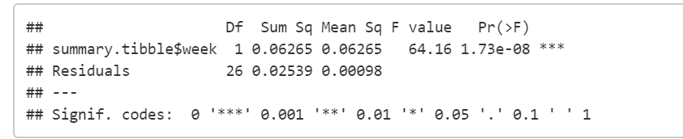

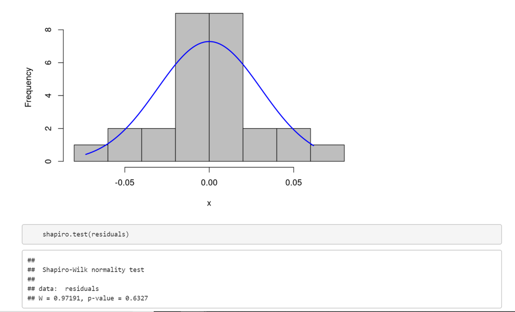

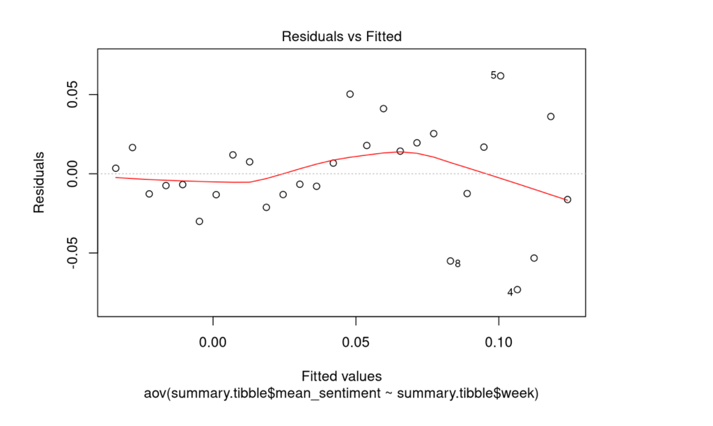